# Efeito das Políticas Públicas sobre a Variação Quantitativa de Pessoas em Situação de Rua no Distrito Federal no ano 2023

Hernany Gomes de Castro

Julho de 2024

## Introdução

O trabalho apresenta o teste das hipóteses sugeridas na lista 4. Na ocasião, considerando as estimativas intervalares realizadas, sugeriu-se a existência de efeitos das variáveis testadas sobre a variação quantitativa de pessoas em situação de rua no Distrito Federal no ano 2023. Em síntese, as hipóteses sugeridas para teste foram as seguintes:

1. O efeito das variáveis **“abordagem_razao”**, **“ecr_razao”**, **“residuos_razao”** e **“seletiva_razao”**, difere segundo os territórios de renda categorizados pelo IPEDF-DIEESE (2024). Propõe-se que a análise do efeito pode ser melhor captada se a área de abrangência utilizada (DF) for desagregada.
2. O aumento de **“abordagem_razao”** e **“ecr_razao”** gera os seguintes efeitos nos territórios sugeridos: a) redução nos grupos de alta e média-alta renda; b) aumento nos grupos de média-baixa e baixa renda.
3. O aumento de **“seletiva_razao”** gera os seguintes efeitos nos territórios sugeridos: a) aumento nos grupos de alta e média-alta renda; b) redução nos grupos de média-baixa e baixa renda.
4. O aumento de **“residuos_razao”** gera os seguintes efeitos nos territórios sugeridos: aumento nos grupos de alta e média-alta renda, como nos grupos de média-baixa e baixa renda.

## Regressão Múltipla

O modelo escolhido para realizar o teste foi a Regressão Múltipla (RM). A RM é um teste estatístico utilizado para analisar a relação entre uma variável dependente e múltiplas variáveis independentes (Hair et al,2009).Portanto, considera-se que a regressão múltipla é uma técnica de análise estatística adequada para investigação das relações de dependência entre as variáveis escolhidas. O objetivo é utilizar valores conhecidos das variáveis independentes métricas para explicar e prever valores da variável dependente. O procedimento de regressão visa garantir a máxima previsão no âmbito do conjunto das variáveis escolhidas.

A aplicação da RM no teste das hipóteses sugeridas no presente trabalho depende, entretanto, do atendimento dos pressupostos da regressão. As variáveis independentes métricas escolhidas devem atender às suposições de linearidade, homocedasticidade e normalidade. Portanto, a proposição de uma variável estatística de regressão requer variáveis independentes, além de uma variável dependente não funcional, que: 1) tenham tamanho amostral > que 20 observações cada uma; 2) atendam às suposições de linearidade, homocedasticidade, normalidade e independência. É preciso, ainda, estabelecer um procedimento para estimação e avaliação do ajuste do modelo, por exemplo, confirmatório, stepwise, forward ou backward, além de procedimentos para identificação de colinearidade, observações influentes, como para medidas corretivas e de validação dos resultados.

A escolha da RM é adequada aos objetivos do presente trabalho, vez que as estimativas realizadas mostram que a variação quantitativa de pessoas em situação de rua no Distrito Federal é sensível às ações das políticas públicas no ano 2023. Essa variação parece manter relação de dependência com variáveis independentes das políticas públicas. O trabalho testou dois procedimentos, stepwise e confirmatório, sendo aplicadas medida corretiva de exclusão de observações ifluentes e de validação de resultados.

A RM foi realizada em linguagem R, no software RStudio, a partir de pacotes nativos e do pacote infer.

## Objetivos

O objetivo é explicar e prever a variação quantitativa de pessoas em situação de rua entre as regiões administrativas do Distrito Federal no ano 2023. Com isso, espera-se identificar ações das políticas públicas que interfiram na variação da quantidade de pessoas em situação de rua no Distrito Federal.

### Variável Dependente

Pessoa em Situação de Rua Ativa é uma classificação realizada pelo Serviço Especializado de Abordagem Social (SEAS), da Secretaria de Estado de Desenvolvimento Social do DF (SEDES), que consiste na contagem de pessoas atendidas em um ponto de concentração e encontradas em outro ponto na cidade, embora sem novo atendimento. Em outras palavras, são pessoas conhecidas e atendidas encontradas em um novo local que não aquele onde o atendimento foi realizado. Essa definição é de interesse para a pesquisa por indicar a circulação da população em situação de rua no Distrito Federal.

### Variáveis Independentes

Foram identificadas 15 (quinze) variáveis independentes para teste, definidas a seguir:

1. **“centropop_razao”**: total atendimentos realizados pelos Centros-pop para cada 100 habitantes do DF.
2. **“creas_razao”**: total atendimentos realizados pelos Creas para cada 100 habitantes do DF.
3. **“refeicao_razao”**: total de unidades de café da manhã, lanche, almoço e jantar servidos pelo Centro pop, para cada 100 habitantes do DF.
4. **“pratocheio_razao”**: total de benefícios do programa prato-cheio pagos para cada 100 habitantes do DF.
5. **“abordagem_razao”**: total de abordagens sociais realizadas pelo Serviço Especializado de Abordagem Social para cada 100 habitantes do DF.
6. **“cadunico_razao”**: total de inscrições e atualizações do cadastro único para cada 100 habitantes do DF.
7. **“aux_vul_razao”**: total de auxílios vulnerabilidade pagos para cada 100 habitantes do DF.
8. **“ecr_razao”**: total de atendimentos realizados pelas equipes do Consultório na rua para cada 100 habitantes do DF.
9. **“upa_razao”**: total de atendimentos realizados nas Unidades de Pronto-atendimento para cada 100 habitantes do DF.
10. **“residuos_razao”**: total de kilos de resíduos coletados pelo Serviço de Limpeza Urbana (SLU) para cada 100 habitantes do DF.
11. **“seletiva_razao”**: total de kilos de resíduos coletados na coleta seletiva pelo SLU para cada 100 habitantes do DF.
12. **“ouvidoria_razao”**: total de ouvidorias recebidas para cada 100 habitantes do DF.
13. **“ocorrencias_razao”**: total de boletins de ocorrências registrados para cada 100 habitantes do DF.
14. **“obitos_razao”**: total de óbitos registrados para cada 100 habitantes do DF.
15. **“drogas_razao”**: total de kilos de maconha e cocaína apreendidos para cada 100 habitantes do DF.

A relação entre as 15 VIs e a VD é considerada estatística, não funcional, tendo em vista que envolve ação independente e pode ter níveis de erro de medida.

Para fins de comparação, calculou-se a razão das variáveis em relação à população do Distrito Federal, com base no Censo IBGE 2022, na escala de 1 (um) unidade da variável para cada 100 (cem) habitantes do DF. A abrangência da estimativa é Distritro Federal.

## Parâmetros

Considerando Hair et al (p.167,2009), adota-se R² mínimo de 42 para 20 variáveis independentes, com significância < 0,05. Além disso, a proporção de n é 1:50 para cada variável. Conforme tabela, a seguir, o menor n encontrado na amostra é de 60, o maior 360, a média é 301 e a soma 6.330.

| names | x |
| --- | --- |
| grupo_renda | 348 |
| densidade | 348 |
| ano | 360 |
| mes | 360 |
| mean_ativos_razao | 337 |
| centropop_razao | 348 |
| creas_razao | 116 |
| refeicao_razao | 360 |
| pratocheio_razao | 123 |
| abordagem_razao | 326 |
| cadunico_razao | 232 |
| aux_vul_razao | 360 |
| ecr_razao | 60 |
| upa_razao | 144 |
| residuos_razao | 360 |
| seletiva_razao | 360 |
| tx_coleta | 360 |
| ouvidoria_razao | 348 |
| ocorrencias_razao | 360 |
| obitos_razao | 360 |
| drogas_razao | 360 |

## Análise Stepwise

O procedimento escolhido para realizar a RM, inicialmente, foi stepwise. Esse procedimento maximiza a variância explicada incremental em cada passo da construção do modelo (Hair et al, 2009). Stepwise consiste na adição das variáveis à equação estatística de acordo à força da correlação. Em outras palavras, nesse processo, a construção do modelo é resultado das estatísticas do procedimento escolhido. Apresenta-se, a seguir, um resumo das correlações identificadas.

| term | estimate | std.error | statistic | p.value |
| --- | --- | --- | --- | --- |
| (Intercept) | 0.0817 | 0.021 | 3.89 | 0.000124 |
| abordagem_razao | 0.494 | 0.0495 | 9.98 | 1.28e-20 |
| (Intercept) | 0.141 | 0.0212 | 6.65 | 1.21e-10 |
| aux_vul_razao | 0.165 | 0.0328 | 5.03 | 7.97e-07 |
| (Intercept) | 0.093 | 0.0344 | 2.7 | 0.00748 |
| cadunico_razao | 10.4 | 1.73 | 5.99 | 8.28e-09 |
| (Intercept) | 0.114 | 0.0232 | 4.92 | 1.41e-06 |
| centropop_razao | 0.0265 | 0.00433 | 6.12 | 2.76e-09 |
| (Intercept) | 0.149 | 0.025 | 5.96 | 3.17e-08 |
| creas_razao | 1.43 | 1.54 | 0.933 | 0.353 |
| (Intercept) | 0.173 | 0.0204 | 8.48 | 7.32e-16 |
| drogas_razao | 0.00622 | 0.00255 | 2.44 | 0.0151 |
| (Intercept) | 0.271 | 0.0547 | 4.96 | 6.56e-06 |
| ecr_razao | -0.082 | 0.34 | -0.241 | 0.81 |
| (Intercept) | 0.103 | 0.0216 | 4.77 | 2.7e-06 |
| obitos_razao | 4.17 | 0.568 | 7.34 | 1.65e-12 |
| (Intercept) | 0.0928 | 0.0215 | 4.32 | 2.1e-05 |
| ocorrencias_razao | 14.9 | 1.84 | 8.09 | 1.09e-14 |
| (Intercept) | 0.145 | 0.0189 | 7.67 | 1.92e-13 |
| ouvidoria_razao | 25.5 | 3.26 | 7.82 | 6.83e-14 |
| (Intercept) | 0.169 | 0.0344 | 4.91 | 2.95e-06 |
| pratocheio_razao | 0.0338 | 0.0251 | 1.35 | 0.181 |
| (Intercept) | 0.0995 | 0.0228 | 4.37 | 1.66e-05 |
| refeicao_razao | 0.000541 | 8.12e-05 | 6.66 | 1.09e-10 |
| (Intercept) | 0.0971 | 0.0242 | 4.02 | 7.34e-05 |
| residuos_razao | 0.0017 | 0.000286 | 5.96 | 6.53e-09 |
| (Intercept) | 0.0939 | 0.0261 | 3.6 | 0.000361 |
| seletiva_razao | 0.0297 | 0.00564 | 5.27 | 2.48e-07 |
| (Intercept) | 0.113 | 0.0184 | 6.14 | 8.58e-09 |
| upa_razao | 3.36 | 1.39 | 2.42 | 0.0168 |

### Resumo do Modelo Stepwise

#### Equação do modelo:

modelo <- lm(mean_ativos_razao ~ cadunico_razao + ecr_razao, data = transito_renda)

Das 16 variáveis testadas, somente as variáveis independentes “cadunico_razao” e “ecr_razao” se aproximaram do atendimento às suposições. O teste de normalidade para “cadunico_razão” resultou em W = 0.90771 e p-valor de < 2.2e-16, enquanto para “ecr_razao” foi de W = 0.5099 e p-valor de 0.0002542. Assim, as variáveis “cadunico_razao” e “ecr_razao”: 1) atendem a suposição de lineralidade; 2) cadunico_razao viola a suposição de homocedasticidade, enquanto ecr_razao atende; 3) ambas violam a suposição de normalidade. As variáveis não chagaram a ser testadas quanto à independência.

As tentativas de normalização dos dados com scale() resultaram em “Not a Number”. Ou seja, os valores mínimos são iguais aos valores máximos.

Conclui-se, portanto, que o procedimento stepwise não foi bem-sucedido para realizar a RM proposta.

#### Análise Residual

cadastrounico_razao

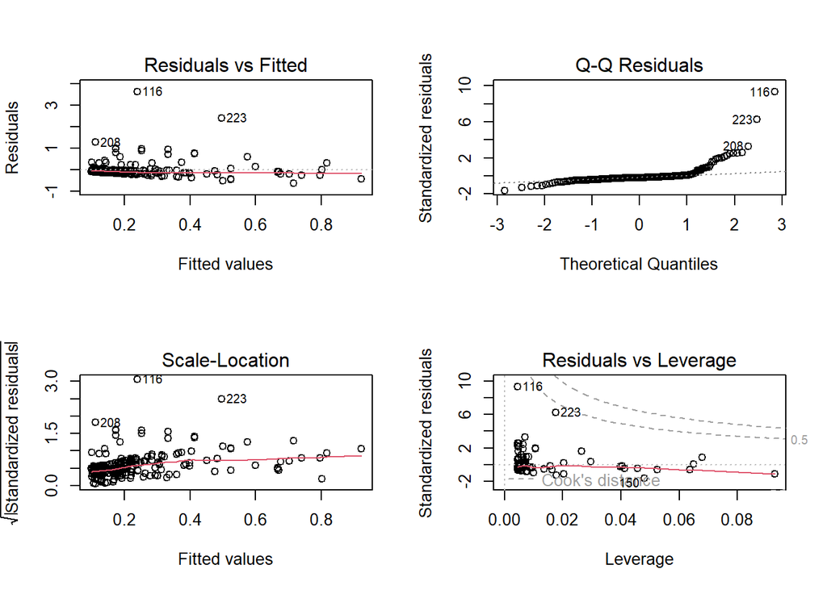

ecr_razao

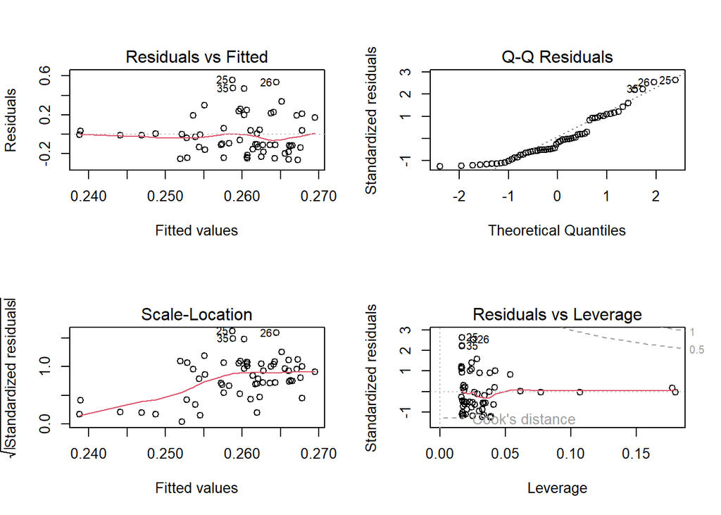

## Análise Confirmatória

A frustração do procedimento stepwise para realização da RM levou ao uso do procedimento confirmatório. Esse procedimento é uma alternativa ao stepwise, em que o pesquisador indica as variáveis independentes a serem incluídas na equação estatística (Hair et al,2009). A principal comparação é em relação ao ajuste geral do modelo, que deve considerar como a multicolinearidade afeta o número e a força das variáveis significantes.

Mantida a variável dependente, as seguintes variáveis independentes foram incluídas no modelo:

1. abordagem_razao
2. ouvidoria_razao
3. ocorrencias_razao
4. ecr_razao
5. seletiva_razao

### Resumo do Modelo Confirmatório

Apresenta-se, a seguir, o resumo do modelo:

| term | estimate | std.error | statistic | p.value |
| --- | --- | --- | --- | --- |
| (Intercept) | 0.0916 | 0.0494 | 1.85 | 0.0696 |
| abordagem_razao | 0.375 | 0.103 | 3.63 | 0.000642 |
| ouvidoria_razao | -33.9 | 10.3 | -3.28 | 0.00183 |
| ocorrencias_razao | 15.2 | 4.95 | 3.07 | 0.00345 |
| ecr_razao | -0.0252 | 0.214 | -0.118 | 0.906 |
| seletiva_razao | -0.0366 | 0.0222 | -1.65 | 0.105 |

#### Equação do modelo:

modelo_conf <- lm(mean_ativos_razao ~ abordagem_razao + ouvidoria_razao + ocorrencias_razao + ecr_razao + seletiva_razao, data = transito_renda)

#### Medidas de Ajuste

O modelo obteve o seguinte desempenho:

- R²: 0.7129
- R² ajustado: 0.6853
- F: 25.83 on 5 and 52 DF
- p-valor: 5.333e-13

O desempenho do modelo atende aos parâmetros estabelecidos (R² mínimo de 42, p-valor < 0,05).

```
##
## Call:
## lm(formula = mean_ativos_razao ~ abordagem_razao + ouvidoria_razao +
##     ocorrencias_razao + ecr_razao + seletiva_razao, data = transito_renda)
##
## Residuals:
##      Min       1Q   Median       3Q      Max
## -0.34656 -0.06064 -0.00152  0.06526  0.30984
##
## Coefficients:
##                    Estimate Std. Error t value Pr(>|t|)
## (Intercept)         0.09158    0.04942   1.853 0.069564 .
## abordagem_razao     0.37480    0.10317   3.633 0.000642 ***
## ouvidoria_razao   -33.89583   10.32165  -3.284 0.001835 **
## ocorrencias_razao  15.16909    4.94890   3.065 0.003446 **
## ecr_razao          -0.02524    0.21350  -0.118 0.906342
## seletiva_razao     -0.03659    0.02218  -1.650 0.105024
## ---
## Signif. codes:  0 '***' 0.001 '**' 0.01 '*' 0.05 '.' 0.1 ' ' 1
##
## Residual standard error: 0.1211 on 52 degrees of freedom
##   (302 observations deleted due to missingness)
## Multiple R-squared:  0.7129, Adjusted R-squared:  0.6853
## F-statistic: 25.83 on 5 and 52 DF,  p-value: 5.333e-13
```

#### Multicolinearidade

O teste vif() rejeitou a existência de multicolinearidade que afete o número e a força das variáveis significantes. O resultado é apresentado a seguir.

```
##   abordagem_razao   ouvidoria_razao ocorrencias_razao         ecr_razao
##          4.227639          2.982327          6.391878          1.156995
##    seletiva_razao
##          1.116989
```

#### Correlação de Resíduos

O teste de Durbin-Watson (WD) verifica a presença de autocorrelação serial nos resíduos de um modelo de regressão. A autocorrelação serial ocorre quando os erros de observações adjacentes em uma série temporal são correlacionados entre si.

Apresenta-se, a seguir, os resultados do teste.

```
##  lag Autocorrelation D-W Statistic p-value
##    1       0.2243252      1.492104    0.01
##  Alternative hypothesis: rho != 0
```

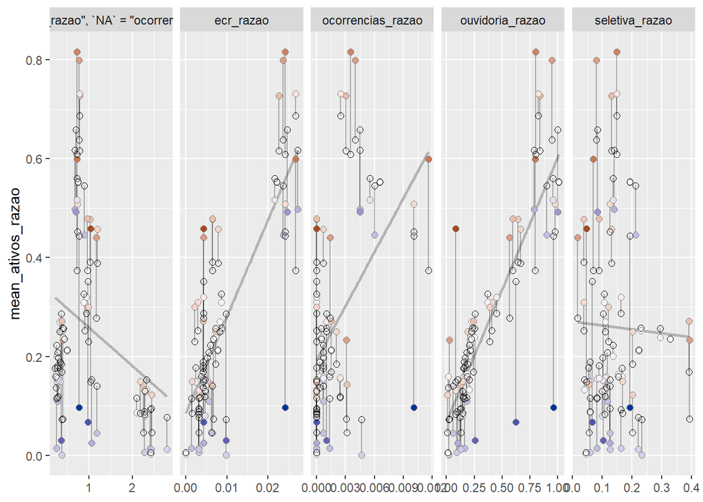

#### Observações Influentes

```
## No Studentized residuals with Bonferroni p < 0.05
## Largest |rstudent|:
##     rstudent unadjusted p-value Bonferroni p
## 104 3.494978          0.0010165     0.056924
```

### Estimação do Modelo e Avaliação do Ajuste Geral

O procedimento confirmatório mostrou-se mais consistente para realização da RM do que o stepwise. Após ajustes decorrentes dos testes realizados para atendimento às suposições da RM, apresenta-se o resumo.

```
##
## Call:
## lm(formula = mean_ativos_razao ~ abordagem_razao + ouvidoria_razao +
##     ocorrencias_razao + ecr_razao + seletiva_razao, data = transito_n)
##
## Residuals:
##      Min       1Q   Median       3Q      Max
## -0.29378 -0.07277 -0.00198  0.05914  0.33388
##
## Coefficients:
##                    Estimate Std. Error t value Pr(>|t|)
## (Intercept)         0.06756    0.04586   1.473   0.1470
## abordagem_razao     0.43384    0.09728   4.460 4.66e-05 ***
## ouvidoria_razao   -19.28807   10.25336  -1.881   0.0658 .
## ocorrencias_razao  11.45859    4.64234   2.468   0.0170 *
## ecr_razao           0.05814    0.19699   0.295   0.7691
## seletiva_razao     -0.02963    0.02024  -1.464   0.1496
## ---
## Signif. codes:  0 '***' 0.001 '**' 0.01 '*' 0.05 '.' 0.1 ' ' 1
##
## Residual standard error: 0.1099 on 50 degrees of freedom
##   (302 observations deleted due to missingness)
## Multiple R-squared:  0.7626, Adjusted R-squared:  0.7388
## F-statistic: 32.12 on 5 and 50 DF,  p-value: 1.678e-14
```

Em síntese,

1. R² = 0.7626.
2. R² ajustado = 0.7388.
3. F = 32.12 on 5 and 50 DF.
4. o p-valor da variável estatística é 1.678e-14.
5. **ouvidoria_razao** e **seletiva_razao** tem sinal negativo, embora sem significância estatística (p-valor > 0.05).
6. **abordagem_razao**, **ocorrencias_razao** e **ecr_razao** tem sinal positivo, embora ocorrencias maior do que abordagem e do que ecr.
7. **abordagem_razao** e **ocorrencias_razao** têm p-valor < 0.05.
8. o maior VIF é ocorrencias: 6.07, seguido de abordagem: 3.92, embora ambos abaixo do valor de referência (10).

Coeficientes do modelo

```
##       (Intercept)   abordagem_razao   ouvidoria_razao ocorrencias_razao
##        0.06756462        0.43383513      -19.28806508       11.45859356
##         ecr_razao    seletiva_razao
##        0.05813988       -0.02962793
```

### Inferência

Os coeficientes para níveis de confiança (95%) do modelo são os seguintes:

```
##                          2.5 %      97.5 %
## (Intercept)        -0.02455239  0.15968163
## abordagem_razao     0.23844182  0.62922844
## ouvidoria_razao   -39.88254933  1.30641917
## ocorrencias_razao   2.13418265 20.78300447
## ecr_razao          -0.33753449  0.45381424
## seletiva_razao     -0.07028903  0.01103317
```

Estimativa do Intervalo de Confiança (95%)

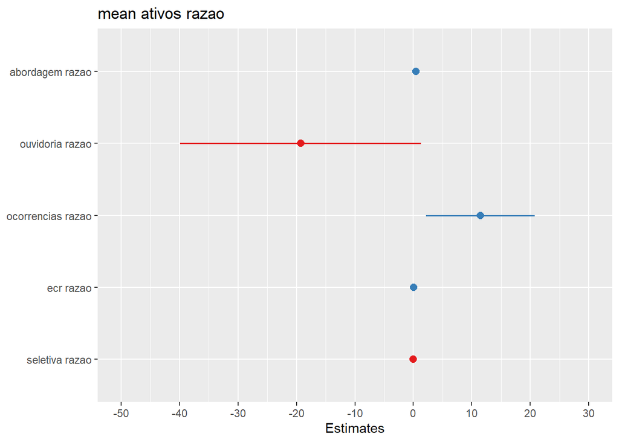

Resíduos

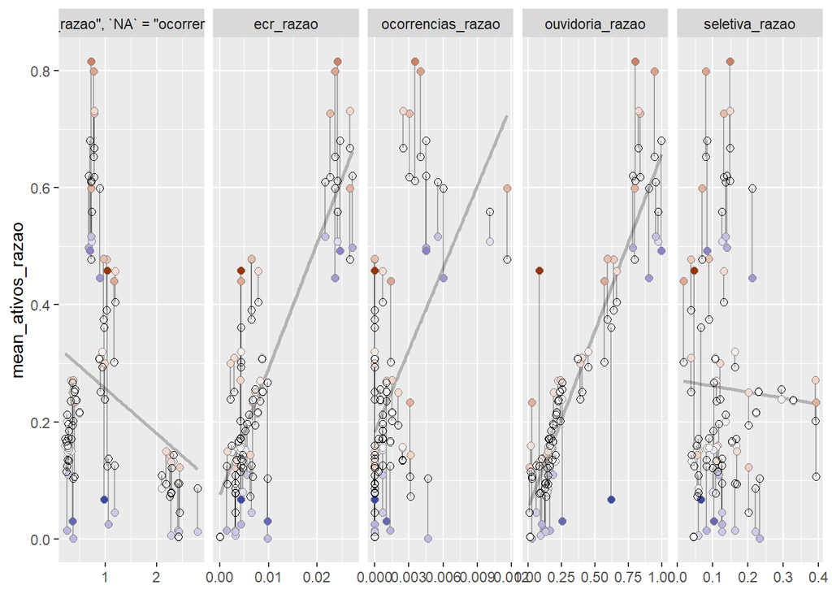

### Validação dos Resultados

Os resultados do modelo foram testados com duas subamostras, a primeira para treinamento e a segunda para validação. A seguir, apresenta-se o resumo de cada uma.

O desempenho do modelo com a subamostra de treinamento foi o seguinte:

1. R² : 0.7617
2. R² ajustado : 0.7311
3. F: 24.93 on 5 and 39 DF
4. p-valor : 3.454e-11
5. **ouvidoria_razao** e **seletiva_razao** tem sinal negativo, sem significância estatística (p-valor > 0.05)
6. **abordagem_razao**, **ecr_razao** e **ocorrencias_razao** tem sinal positivo, embora **abordagem_razao** e **ocorrencias_razao** com significância estatística e **ecr_razao** sem significância estatística. Ocorrências tem estimativa maior do que abordagem
7. o maior VIF é de **ocorrencias_razao**: 6.63, seguido de **abordagem_razao**: 4.45

O desempenho do modelo com a subamostra de validação foi o seguinte:

1. R²: 0.9146
2. R² ajustado: 0.8292.
3. F: 10.71 on 5 and 5 DF
4. p-value : 0.01053
5. **ouvidorias_razao** e **seletiva_razao** têm sinal negativo, enquanto as demais variáveis têm sinal positivo, embora todas sem significância estatística (p-valor > 0.05)
6. o maior VIF é **seletiva_razao**: 8.911, seguida de **abordagem_razao**: 7.40

### Performance do Modelo Validado

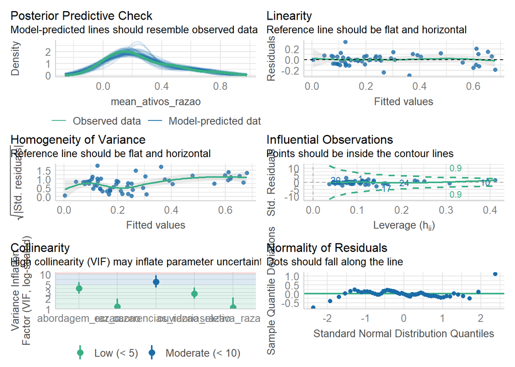

## Teste de Hipótese Nula

A validação da variável estatística permite testar as hipóteses sugeridas na lista 4, embora com adapatações. O teste de hipótese nula pode ser realizado considerando a variável estatística do modelo de regressão múltipla validado. Para realizar esse teste foi utilizado o pacote infer do R. Portanto, o teste compara o efeito da variável estatística entre os grupos de RA’s organizados por renda propostos pelo IPEDF-DIEESE (2024).

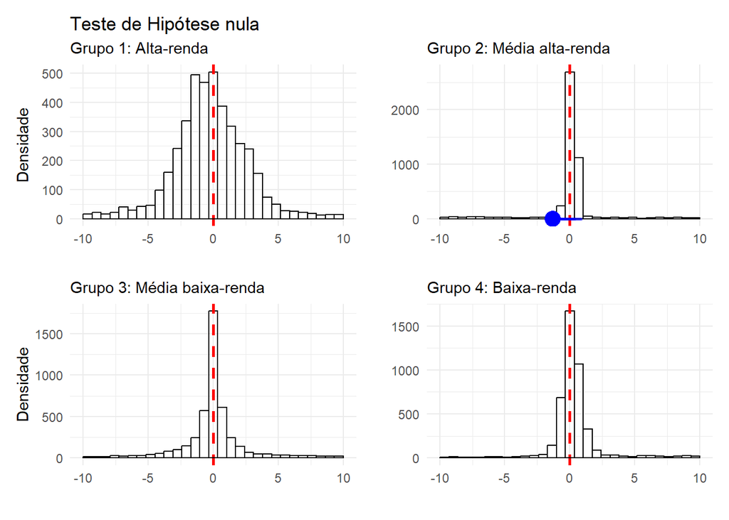

Ainda que o gráfico sugira a rejeição da hipótese nula para o grupo 2, de “média-alta-renda”, a hipótese nula prevalece porque o intervalo de confiança passa por zero, conforme tabela a seguir:

| term | lower_ci | upper_ci |
| --- | --- | --- |
| abordagem_razao | -0.261 | 0.885 |
| ecr_razao | -0.832 | 0.995 |
| intercept | -0.653 | 0.389 |
| ocorrencias_razao | -37.6 | 29.3 |
| ouvidoria_razao | -73.9 | 60.8 |
| seletiva_razao | -0.315 | 0.491 |

## Conclusões

O objetivo do trabalho é explicar e prever a variação quantitativa de pessoas em situação de rua entre as regiões administrativas do Distrito Federal no ano 2023. A expectativa é identificar ações das políticas públicas que interfiram na variação da quantidade de pessoas em situação de rua no Distrito Federal. Considerando a estimativa realizada na lista 4, sugeriu-se testar as seguintes hipóteses:

1. O efeito das variáveis **“abordagem_razao”**, **“ecr_razao”**, **“residuos_razao”** e **“seletiva_razao”**, difere segundo os territórios de renda categorizados pelo IPEDF-DIEESE (2024). Propõe-se que a análise do efeito pode ser melhor captada se a área de abrangência utilizada (DF) for desagregada
2. O aumento de **“abordagem_razao”** e **“ecr_razao”** gera os seguintes efeitos nos territórios sugeridos: a) redução nos grupos de alta e média-alta renda; b) aumento nos grupos de média-baixa e baixa renda
3. O aumento de **“seletiva_razao”** gera os seguintes efeitos nos territórios sugeridos: a) aumento nos grupos de alta e média-alta renda; b) redução nos grupos de média-baixa e baixa renda
4. O aumento de **“residuos_razao”** gera os seguintes efeitos nos territórios sugeridos: aumento nos grupos de alta e média-alta renda, como nos grupos de média-baixa e baixa renda

O modelo validado de regressão múltipla demonstrou poder explicativo e preditivo satisfatório. Sugere-se que a cada 1 unidade de variação na quantidade de pessoas em situação de rua no DF no ano 2023, 0.83 podem ser explicados e previstos pela variável estatística da regressão múltipla realizada com base no procedimento confirmatório.

Considerando o uso do modelo para avaliar possíveis efeitos sobre a variação quantitativa de pessoas em situação de rua nas RA’s agrupadas por renda (IPEDF-DIEESE,2021), se conclui, estatisticamente, que **Os resultados do teste de hipótese sugerem a confirmação da hipótese nula**. Portanto, a variável estatística testada na regressão múltipla não identificou efeito significativo sobre a variação da quantidade de pessoas em situação de rua no Distrito Federal, no ano 2023, que justifique a rejeição da hipótese nula em quaisquer dos 04 (quatro) grupos de renda do IPEDF-DIEESE (2021).

A confirmação da hipótese nula, a partir da variável estatística validada, sugere algumas questões importantes sobre o efeito das políticas públicas em relação à variação quantitativa de pessoas em situação de rua. Tais questões são consideradas no âmbito da variável estatística e não a partir do isolamento e independência de cada variável. Por exemplo:

## Referência bibliográfica

- ANGRIST, J. D. Mostly Harmless Econometrics: An Empiricist’s Companion. [s.d.].
- CERVI, E. U. **Manual de métodos quantitativos para iniciantes em ciência política**. [s.l.] Emerson Urizzi Cervi, 2017.

  ___. **Manual de métodos quantitativos para iniciantes em ciência política - vol. 2**. [s.l.] Emerson Urizzi Cervi, 2019.
- HAIR, J. F. J. et al. Análise Multivariada De Dados. 6o ed. Porto Alegre: Bookman, 2009.
- MCCONVILLE, C. I. AND A. Y. K. F. BY K. S. Statistical Inference via Data Science (MODERNDIVE). [s.l: s.n.].
- Pacote Infer. Disponível em: https://infer.netlify.app/. Acesso em: 20 jun. 2024.
- VERZANI, J. Using R for introductory statistics. Boca Raton, Fla.: Chapman & Hall/CRC, 2005.
- WICKHAM, H. **R for Data Science (2e)**. Disponível em: <https://r4ds.hadley.nz/\>. Acesso em: 22 mar. 2024.